# 36-315 Homework 06, Fall 2021

SOLUTIONS

Due Tuesday, October 12, 2021 by 11:59pm

For this assignment we will use a dataset on heart disease obtained from Kaggle. The original dataset is part of [the UCI Machine Learning Repository](https://archive.ics.uci.edu/ml/index.php). The link to the dataset can be found [here](https://raw.githubusercontent.com/zjbranson/315SFall2021/main/heart.csv). Descriptions of the dataset can be found [here](https://raw.githubusercontent.com/zjbranson/315Fall2021/main/heart_description.txt). More information is available on Kaggle [here](https://www.kaggle.com/ronitf/heart-disease-uci), but everything you need to know for this homework is in the Github links.

Here is the code to read in the dataset:

```r
heart = read.csv("https://raw.githubusercontent.com/zjbranson/315Fall2021/main/heart.csv")
#ensure the categorical variables are factors
heart$sex = factor(heart$sex)
heart$cp = factor(heart$cp)
heart$fbs = factor(heart$fbs)
heart$restecg = factor(heart$restecg)
heart$exang = factor(heart$exang)
heart$slope = factor(heart$slope)
heart$thal = factor(heart$thal)
heart$target = factor(heart$target)
```

# Problem 1: Lab exam practice problems (26 points)

For this problem, we will review old material (Homeworks 1-5) that act as practice problems for the lab exam (which will be released at 8am Friday October 15, and due 8pm Friday October 15).

1. (8pts) [Professor P. Waggoner](https://en.wikipedia.org/wiki/Paul_Waggoner) would like to better understand the extent of heart problems in the `heart` dataset. For this part, create a plot that visualizes `cp` (which stands for “chest pain” type) and `sex`, such that you’re best able to answer the following questions:
- Which types of chest pain are most common in the data? Which are least common?
- Are females more likely to have low-severity chest pain (0 or 1) or high-severity chest pain (2 or 3)? Are males more likely to have low-severity chest pain (0 or 1) or high-severity chest pain (2 or 3)?

Be sure your plot is appropriately titled/labeled/colored, and be sure to read the description of the variables [here](https://raw.githubusercontent.com/zjbranson/315Fall2021/main/heart_description.txt) to understand how this variable is coded. In particular, when creating labels for `sex` in your graph, be sure that your labels use “male” and “female” instead of the less sensible 0 and 1.

After you’ve made your graph, answer each of the above questions in 1-3 sentences.

*We decided to make a stacked bar plot that visualizes chest pain and sex:*

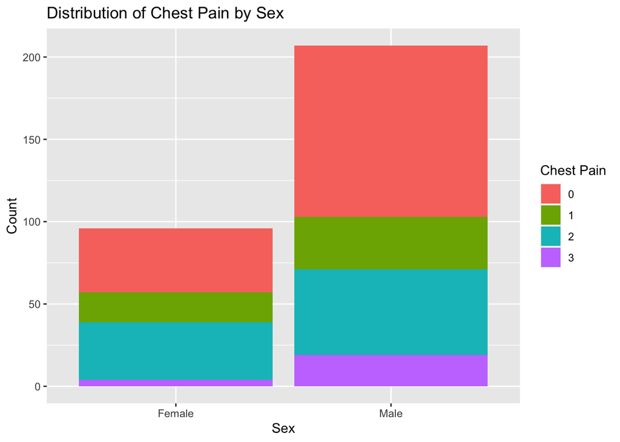

```r
library(tidyverse)
ggplot(data = heart, aes(x = factor(sex), fill = factor(cp))) +
  geom_bar() + labs(title = "Distribution of Chest Pain by Sex", x = "Sex", y = "Count", fill = "Chest Pain") +
  scale_x_discrete(labels = c("Female", "Male"))
```

*[Note that `sex` and `cp` are categorical variables, and we had to treat them as such by putting `factor()` around these variables in our code. If we did not do this, `R` would treat these variables as quantitative (because they’re coded numerically), which would create an inappropriate plot.]*

*Now we’ll answer the above questions:*

- Which types of chest pain are most common in the data? Which are least common?

*It looks like low chest pain (`cp = 0`) is the most common, and moderate chest pain (`cp = 2`) is also somewhat common. Meanwhile, severe chest pain (`cp = 3`) is the least common in the data (which I guess is a good thing).*

- Are females more likely to have low-severity chest pain (0 or 1) or high-severity chest pain (2 or 3)? Are males more likely to have low-severity chest pain (0 or 1) or high-severity chest pain (2 or 3)?

*It appears that females are about equally likely to have low-severity or high-severity chest pain (because the total area of `cp = 0` and `cp = 1` bars within the female group is about equal to the total area of `cp = 2` and `cp = 3` bars within the female group). Meanwhile, males are somewhat more likely to have low-severity chest pain than high-severity chest pain (because the total area of `cp = 0` and `cp = 1` bars within the male group is larger than the total area of `cp = 2` and `cp = 3` bars within the male group).*

*[Although you did not need to do this for this part, you could figure out the actual proportions for females with some non-graphical EDA:]*

```r
prop.table(table(subset(heart, sex == 0)$cp))
```

```
##
##          0          1          2          3
## 0.40625000 0.18750000 0.36458333 0.04166667
```

*[The above indicates that roughly 60% of females have low-severity chest pain, and 40% have high-severity chest pain. Thus, it is also okay if you said that females are more likely to have low-severity chest pain than high-severity chest pain, but it is somewhat difficult to tell from the above graph, since the proportions are fairly close.]*

2. (4pts) Now Professor Waggoner would like to understand if `cp` is associated with other variables in the data. He has the following questions:
- Do you think `cp` and `sex` are independent?
- Do you think `cp` and `target` are independent?

Run statistical analyses that allow you to answer both of these questions. State Yes or No for each question, and explain in 1-2 sentences how you arrived at your answer using your statistical analyses (which you should include in this part as well).

*Both of these questions ask us to assess if two categorical variables are independent. At this point, bells (or some other musical instrument of your choice) should be ringing in your head: The most appropriate analysis is a chi-squared test. Here are the corresponding chi-squared tests:*

```r
chisq.test(table(heart$cp, heart$sex))
```

```
##
##  Pearson's Chi-squared test
##
## data:  table(heart$cp, heart$sex)
## X-squared = 6.8221, df = 3, p-value = 0.07779
```

```r
chisq.test(table(heart$cp, heart$target))
```

```
##
##  Pearson's Chi-squared test
##
## data:  table(heart$cp, heart$target)
## X-squared = 81.686, df = 3, p-value < 2.2e-16
```

*Now we’ll answer the two questions:*

- Do you think `cp` and `sex` are independent?

*Yes. We see the p-value for this chi-squared test is 0.08; this is just above the traditional $\alpha = 0.05$ value, but nonetheless we fail to reject the null hypothesis that these variables are independent, thereby concluding that `cp` and `sex` are independent.*

- Do you think `cp` and `target` are independent?

*No. We see the p-value for this chi-squared test is quite small and certainly less than 0.05. Thus, we reject the null hypothesis that these variables are independent, thereby concluding that `cp` and `target` are dependent.*

3. (6pts) Professor Waggoner appreciates your work in Part B, but he isn’t completely satisfied. In particular: He realizes now that he doesn’t just want to know whether or not two variables are independent. Rather: If two variables are *not* independent, he would like to more fully understand in which ways they are dependent.

Thus, for this part, make a plot that acts as a “graphical follow-up” to Part B. In other words: If you do not think that `cp` and `sex` are independent, then make a plot that assesses in which ways they are dependent. Similarly, if you do not think that `cp` and `target` are independent, then make a plot that assesses in which ways they are dependent. After you’ve made the plot, interpret it in 1-3 sentences, being sure to describe in which ways the two variables seem to be dependent on each other.

*As we’ve discussed in class, a mosaic plot acts as a natural graphical analog to the chi-squared test. Below we made a mosaic plot for `cp` and `target`, since we rejected the null hypothesis for the chi-squared test for these variables in Part B. We colored the mosaic plot with Pearson residuals, such that we could see unusually high or low counts for the different `cp`/`target` combinations. [By “unusually high” and “unusually low,” we mean in reference to counts we would expect if these two variables were independent.]*

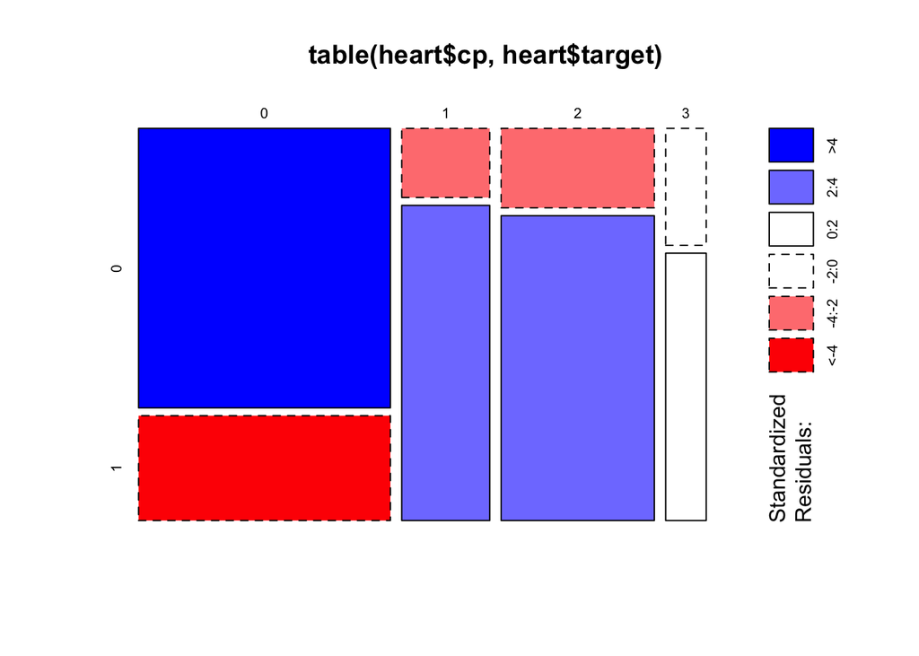

```r
mosaicplot(table(heart$cp, heart$target), shade = TRUE)
```

*We see that there are an unusually high number of subjects with `cp = 0` and `target = 0`; this corresponds to low-severity chest pain and no heart condition. Meanwhile, we see that there are more subjects with a heart condition (`target = 1`) who also have moderate chest pain (`cp = 1` or `cp = 2`) than we would expect if these variables were independent. Thus, the mosaic plot serves as evidence that having a heart condition is associated with higher levels of chest pain, which is intuitive.*

4. (8 points) As a final exploration of this dataset, Professor Waggoner wants to turn his attention to the variables `thalach` and `ca`. In particular, he wants a plot that does the following:
- Visualizes the distribution of `thalach` conditional on `ca`.
- Shows you the sample size for each `ca` value (i.e., the sample size of `ca = 0` people, the sample size of `ca = 1` people, etc.)

Be sure that your plot is appropriately labeled/titled/colored, and that you’ve specified certain `ggplot` arguments (rather than just using default values) to ensure that the conditional distribution is accurately visualized (from your point of view).

*Here we used a histogram of `thalach` facetted by `ca` (see below). Each facet allows us to see the distribution of `thalach` conditional on `ca`. Meanwhile, the total area of bars in each facet gives us an idea of the sample size of each `ca` value.*

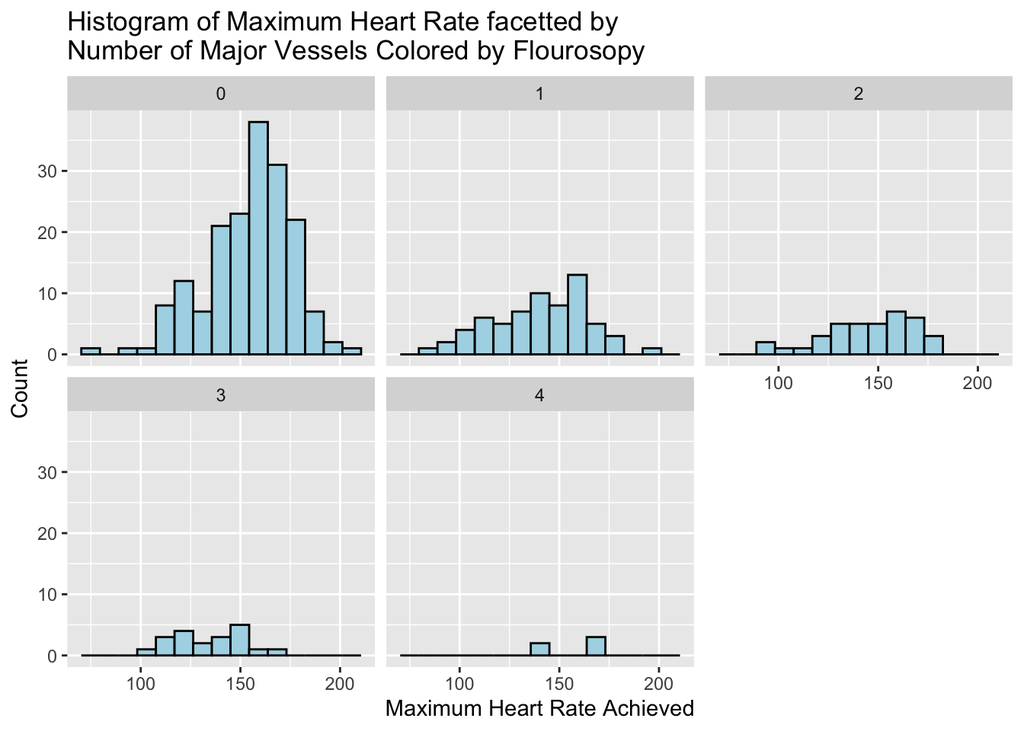

```r
ggplot(heart, aes(x=thalach)) +
  geom_histogram(color = "black", fill = "lightblue", bins = 15) +
  facet_wrap(~ ca) +
  labs(title = "Histogram of Maximum Heart Rate facetted by \nNumber of Major Vessels Colored by Flourosopy",
       x = "Maximum Heart Rate Achieved", y = "Count")
```

After you’ve made your plot, answer the following questions:

- Describe the conditional distribution of `thalach` given `ca`. In particular: Compare and contrast the distribution of `thalach` for different values of `ca`.

*The distribution of `thalach` seems pretty similar across `ca` values, albiet with different sample sizes. The center of each distribution tends to be around `thalach = 150` regardless of `ca`. We can note that the distributions for `ca = 0` and `ca = 1` seem fairly unimodal and slightly left-skewed, whereas the distributions for other `ca` values seem slightly more uniformly-distributed; however, this is likely just due to the small sample sizes for these `ca` values.*

- Compare and contrast the sample sizes for each `ca` value. In particular: Which `ca` values are most common, and which are least common?

*We can see that `ca = 0` is the most common, while `ca = 4` is the least common. More generally, it seems like smaller `ca` values are more common than higher value ones. This is intuitive, since a major vessel being colored by fluoroscopy denotes severe issues with the heart.*

**Hint**: You should view `ca` as a categorical variable for this problem (even though it is technically a discrete/quantitative variable). If you can only come up with a plot that visualizes the distribution of `thalach` conditional on `ca` (but not the sample size of `ca`), you can use additional code to answer the `ca` sample size question; however, you will only get partial credit.

# Problem 2: Old `age`? More like `oldpeak`. (41 points)

In this problem we will assess the relationship between `age` and `oldpeak`. The variable `oldpeak` has a complicated definition, and I don’t want you to focus too much on the nuance of interpreting this variable—all you need to know is that a higher `oldpeak` variable is associated with worse heart health.

1. (10pts) For this part, make three scatterplots.
- Make a scatterplot with `age` on the x-axis and `oldpeak` on the y-axis. Add a linear regression line to the plot; the line should be in dark blue (which is the default for `ggplot`). Don’t add standard errors to the plot.
- Make a scatterplot with `age` on the x-axis and `oldpeak` on the y-axis. Add a quadratic regression line to the plot; the line should be a color other than dark blue. Don’t add standard errors to the plot.
- Make a scatterplot with `age` on the x-axis and `oldpeak` on the y-axis. Add a loess-smoothed regression line to the plot; the line shouldn’t be dark blue or the color you chose for the quadratic regression line. Don’t add standard errors to the plot.

Thus, for this part you need to make three scatterplots, all of which display `age` and `oldpeak`, but with different regression lines that are different colors. After you’ve made your three plots, describe the trend suggested by each plot in 1-2 sentences.

```r
library(gridExtra)
```

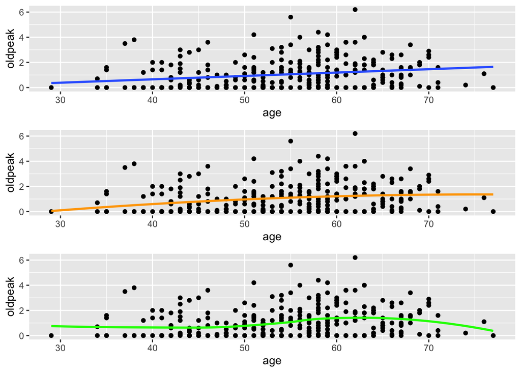

```r
linPlot = ggplot(heart,
    aes(x = age, y = oldpeak)) +
    geom_point() +
    geom_smooth(method = lm, se = FALSE)

quadPlot = ggplot(heart,
    aes(x = age, y = oldpeak)) +
    geom_point() +
    geom_smooth(method = lm, se = FALSE,
        formula = y ~ x + I(x^2),
        color = "orange")

loessPlot = ggplot(heart,
    aes(x = age, y = oldpeak)) +
    geom_point() +
    geom_smooth(method = loess, se = FALSE,
                col = "green")

grid.arrange(linPlot, quadPlot, loessPlot)
```

*For the linear regression, we see a positive trend, suggesting that higher ages are associated with higher `oldpeak` values. This is intuitive, since we would expect that people with higher ages would (unfortunately) have worse heart health.*

*Meanwhile, for the quadratic regression, the trend is fairly similar there’s still a positive trend, where higher ages are associated with higher `oldpeak` values - but now we see that estimated `oldpeak` values tend to “plateau” or “level off” for high ages.*

*Finally, for the loess curve, the overall trend between `age` and `oldpeak` is much less clear here: We see that the estimated `oldpeak` is about the same for ages below 50, for ages between 50 and 65 we see the positive trend we noted in Parts A and B, and there is a downward trend for ages above 65 (meaning older `age` is associated with lower `oldpeak` values). This is perhaps intuitive: Most fatal heart conditions occur between ages 50 and 65, so if you survive past 65, you may be less likely to have severe heart conditions (because if you, counterfactually, had severe heart conditions, you may not have made it past 65). [Note: This is purely my own speculation about the graph; I’d have to ask my in-residency cousin to see if this is at all true.]*

2. (6pts) I could ask you to compare and contrast the three different plots you made in Part A, but it can be confusing/frustrating to have to look back and forth between three different plots. When comparing different statistical models, it can often be helpful to plot all of the resulting regression lines on the same plot.

So, that’s what I’m going to ask you to do here: Again make a scatterplot with `age` on the x-axis and `oldpeak` on the y-axis, with the three regression lines you made in Part A all added to the same scatterplot. Again, be sure that the regression lines are all different colors.

*Here is the desired plot:*

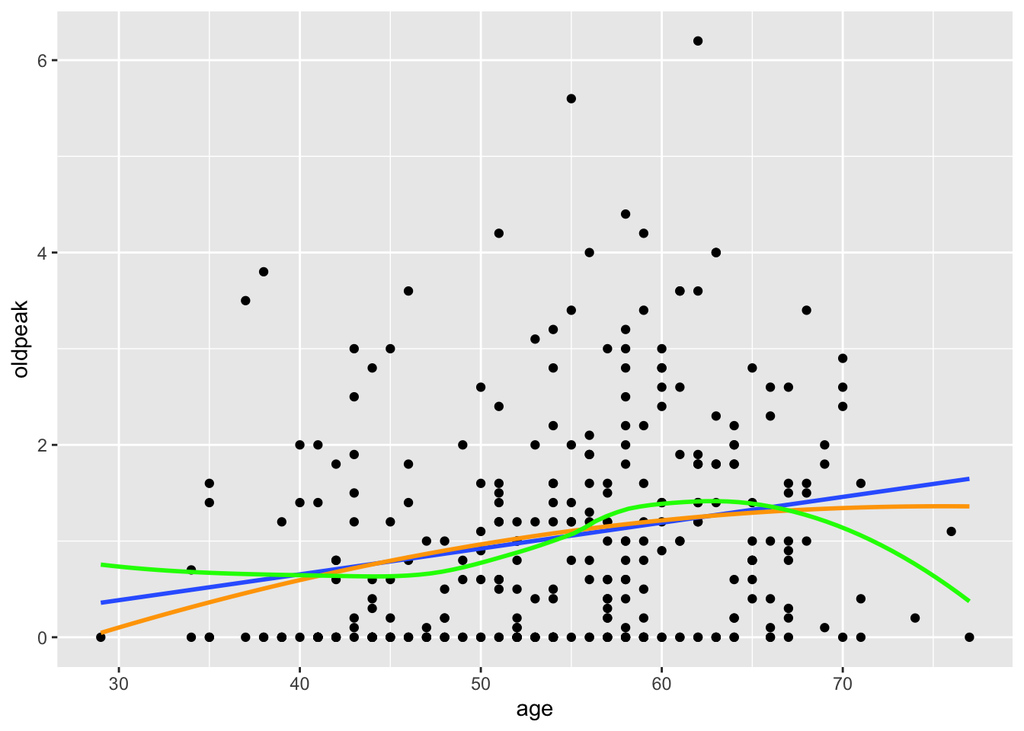

```r
ggplot(heart,
    aes(x = age, y = oldpeak)) +
    geom_point() +
    geom_smooth(method = lm, se = FALSE) +
  geom_smooth(method = lm, se = FALSE,
        formula = y ~ x + I(x^2),
        color = "orange") +
  geom_smooth(method = loess, se = FALSE,
                col = "green")
```

After you’ve made the plot, compare and contrast the estimated `oldpeak` predicted by the three regression lines. In particular, answer the following:

- For which ages do the regression lines most agree in their predictions for `oldpeak`?

*The regressions most agree for moderate ages (between 40 and 65), especially the linear regression and quadratic regressions. We can also note an intersection between these three lines around `age = 40` and `age = 65`.*

- For which ages do the regression lines most disagree in their predictions for `oldpeak`?

*They most disagree for extreme ages (ages less than 40 and ages greater than 65). They tend to disagree more as the ages get more extreme; this is intuitive: As the ages get more extreme, the regressions need to extrapolate more, and thus predicted `oldpeak` values rely more on a particular model specification.*

- Are some regression lines more similar to each other than others? If so, which ones?

*The linear and quadratic regression lines are the most similar to each other; in fact, the lines are in near-perfect agreement for moderate ages. The loess regression is essentially “the odd regression out” (i.e., the regression that’s more different than the others).*

3. (6pts) [Professor E. Korman](https://en.wikipedia.org/wiki/Rolo_Tomassi) is interested in the linear regression you plotted in Parts A and B. In particular, she wants to know: Is the linear trend you plotted in Part A statistically significant? Please provide some code to answer this question (in addition to answering the question itself). Your code should include coefficient estimates for a linear model; so, after you’ve answered Professor Korman’s question, write out an interpretation of each coefficient estimate in the linear model. Be sure that your interpretations are in terms of the context of the data (i.e., you mention the specific variables that are used in the linear model).

*Here we’ll use the `lm()` function to run the linear regression between `age` and `oldpeak` that we visualized in Part A and Part B:*

```r
summary(lm(oldpeak ~ age, data = heart))
```

```
##
## Call:
## lm(formula = oldpeak ~ age, data = heart)
##
## Residuals:
##     Min      1Q  Median      3Q     Max
## -1.6473 -0.8418 -0.3519  0.5702  4.9554
##
## Coefficients:
##              Estimate Std. Error t value Pr(>|t|)
## (Intercept) -0.420048   0.397085  -1.058 0.290981
## age          0.026848   0.007204   3.727 0.000232 ***
## ---
## Signif. codes:  0 '***' 0.001 '**' 0.01 '*' 0.05 '.' 0.1 ' ' 1
##
## Residual standard error: 1.137 on 301 degrees of freedom
## Multiple R-squared:  0.04411,    Adjusted R-squared:  0.04093
## F-statistic: 13.89 on 1 and 301 DF,  p-value: 0.0002317
```

*We see that the p-value for the slope of `age` is 0.0002, and the estimated slope is positive (0.03). Thus, the positive trend that we saw in Part A is indeed statistically significant: We formally conclude that there is a non-zero slope for `age`, at least for this regression model, because we reject the null hypothesis that the slope is 0.*

*Meanwhile, here are our interepretations of the two estimated coefficients in this linear regression model:*

- *We see that the estimated intercept is -0.42. This means that the estimated mean `oldpeak` for `age = 0` subjects is -0.42. (Note: No, it does not make sense to consider `age = 0` subjects, but this is nonetheless the correct interpretation of the intercept.)*
- *We see that the estimated slope for `age` is 0.027. This means that the mean `oldpeak` is estimated to increase by 0.027 for every one-year increase in `age`.*
4. (5pts) Looking at your answer in Part C, Professor Korman gets confused. She says, “It looks like this model is estimating that the average `oldpeak` for some people is negative, which doesn’t even make sense. Why is your model giving these nonsense estimates?” Answer the following questions for Professor Korman:
- For what ages (in whole numbers) does the linear model estimate that `oldpeak` is negative?

*For ages 15 and below the model estimates `oldpeak` to be negative. To understand how we arrived at this answer, note that the estimated `oldpeak` for any given age is:*

$-0.420048 + 0.026848 \cdot \text{age}$

*Setting this equal to zero and solving for age, we get:*

$age = 0.420048/0.026848 = 15.64541 \approx 15$

*Here we rounded down because `age = 16` results in a very slightly positive esitmated `oldpeak`. Thus, for ages 15 and less, we do indeed estimate `oldpeak` to be negative.*

- Explain to Professor Korman in 1-3 sentences why this model may estimate `oldpeak` to be negative for some ages, even though we don’t observe any negative `oldpeak` measurements in the data.

*Note that we only observe subjects as young as 29 in the `heart` dataset; thus, any predictions of `oldpeak` for ages 15 and below are based entirely on extrapolation from the linear regression model. Large extrapolations from linear regression models (and other regression models) can lead to nonsensical estimates like this, which is why it is generally dangerous to trust predictions based on extrapolations.*

*[[Here’s a relevant XKCD comic](https://xkcd.com/605/) on extrapolation.]*

**Hint**: If you’re confused about this question because you don’t think your model estimates `oldpeak` to be negative for anyone, this may suggest you need to go back and check your code for your linear regression (or think more carefully about your regression output).

5. (8pts) Now Professor Korman wants to assess if the linear regression assumptions are tenable for the linear regression you visualized in Part A and interpreted in Part C. For this part, make a residual-versus-fit plot **with a loess curve added to the plot** (with a 95% confidence interval along the line). Then, interpret the plot in terms of the equal variance and linearity assumptions. Specifically, answer these questions:
- Do you think the equal variance assumption is Definitely Tenable, Somewhat Tenable, Somewhat Not Tenable, or Definitely Not Tenable? Pick one of these four options, and then explain in 1-3 sentences.

*The equal variance assumption seems Somewhat Not Tenable here; we can see that the vertical variance of the residuals seems to be higher in the middle of the plot than on the extreme ends of the plot.*

- Do you think the linearity assumption is Definitely Tenable, Somewhat Tenable, Somewhat Not Tenable, or Definitely Not Tenable? Pick one of these four options, and then explain in 1-3 sentences.

*The linearity assumption seems Somewhat Tenable here. The horizontal line at zero is almost completely contained within the 95% confidence interval, which suggests that the trend is not significantly different from no trend around the zero line. However, it is mildly concerning that the zero line is outside the confidence interval at the far right-end of the plot; thus, it is fine if you said Somewhat Not Tenable for this plot.*

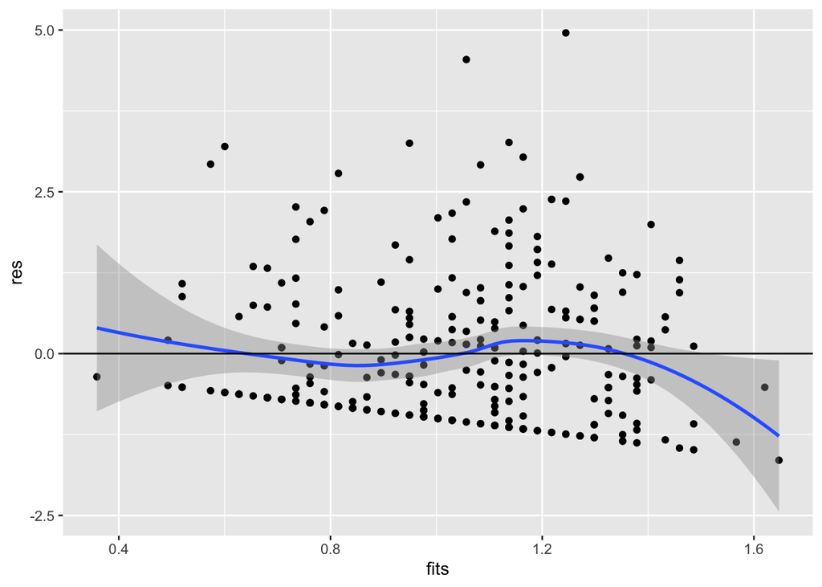

```r
fits = fitted(lm(oldpeak ~ age, data = heart))
res = residuals(lm(oldpeak ~ age, data = heart))

ggplot(data.frame(fits = fits, residuals = res),
    aes(x = fits, y = res)) + geom_point() + geom_smooth(method = "loess", se = TRUE) +
geom_hline(yintercept = 0)
```

6. (6pts) Finally, Professor Korman wants to assess the Normality assumption in linear regression. This is equivalent to assessing if the residuals are Normally distributed. Assess this assumption in two ways:
- Make a plot that visualizes the marginal distribution of the residuals.
- Conduct a statistical analysis that tests whether or not the residuals are Normally distributed.

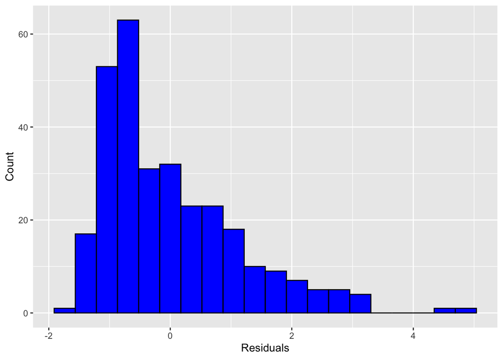

```r
ggplot(data.frame(residuals = res), aes(x = res)) + geom_histogram(fill = "blue", color = "black", bins = 20) + labs(x = "Residuals", y = "Count")
```

```r
ks.test(res, "pnorm", mean = mean(res), sd = sd(res))
```

```
##
##  One-sample Kolmogorov-Smirnov test
##
## data:  res
## D = 0.13448, p-value = 3.48e-05
## alternative hypothesis: two-sided
```

After you’ve done this, state whether you think the Normality assumption is Definitely Tenable, Somewhat Tenable, Somewhat Not Tenable, or Definitely Not Tenable. Pick one of these four options, and then explain in 1-3 sentences.

*The Normality assumption is Definitely Not Tenable. From the histogram there is a clear right-skew in the residuals which looks very non-Normal. Furthermore, we ran a one-sample KS test to test whether the residuals are Normally distributed, and we reject the null hypothesis that the residuals are Normally distributed. The p-value is quite small, suggesting a large deviation from Normality. [You could have also used the Shapiro-Wilk test to test for Normality. In fact this is the preferable test, in the sense that it has more statistical power when assessing Normality specifically; but, we’ve focused on KS tests, which is why I ran it here.]*

**Hint**: Even though this is technically a question about linear regression, it’s really a review of concepts you learned on Homework4. So, if you’re unsure how to tackle this problem, I would go back to that homework.

# Problem 3: Let’s stay positive (11 points)

Looking at the work you did in Problem 2, Professor Korman becomes interested in the subset of the data where `peak` is *not* equal to zero. The following code defines this subset for you:

```r
oldPeakNotZero = subset(heart, oldpeak != 0)
```

1. (5pts) First, make two plots: One that visualizes the distribution of `oldpeak` within the `oldPeakNotZero` dataset, and one that visualizes the distribution of the *square root* of `oldpeak` within the `oldPeakNotZero` dataset. Make sure your plots are appropriately labeled/titled/colored, such that it’s clear which plot shows which distribution.

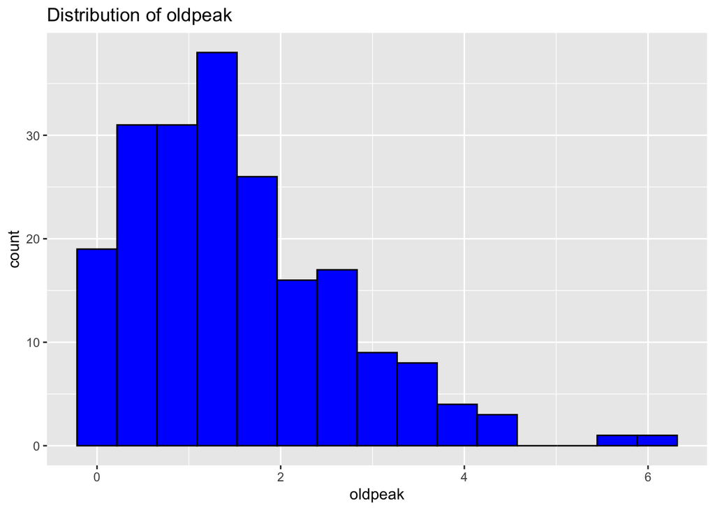

```r
ggplot(oldPeakNotZero, aes(x = oldpeak)) + geom_histogram(fill = "blue", color = "black", bins = 15) + labs(title = "Distribution of oldpeak")
```

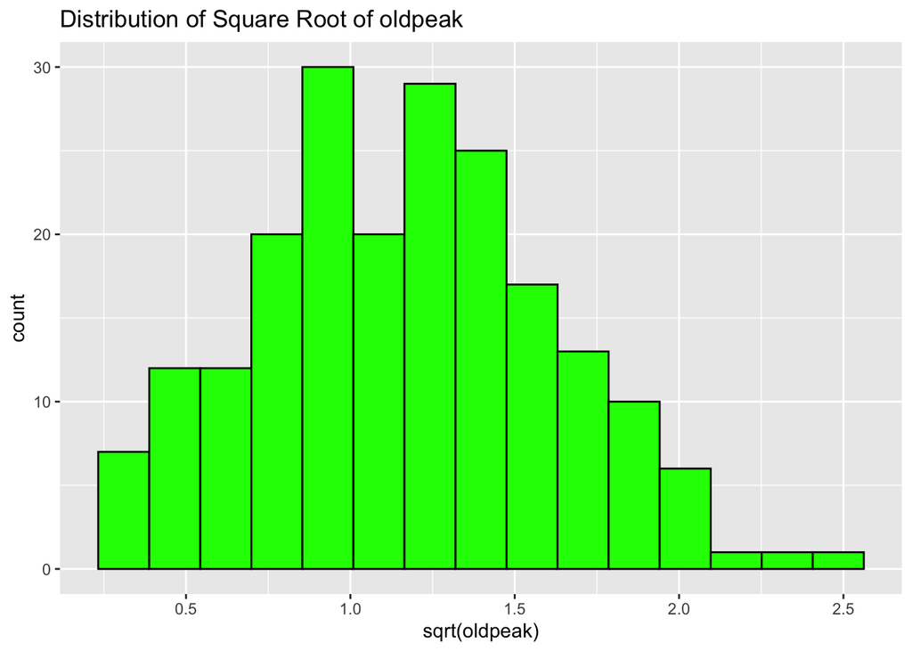

```r
ggplot(oldPeakNotZero, aes(x = sqrt(oldpeak))) + geom_histogram(fill = "green", color = "black", bins = 15) + labs(title = "Distribution of Square Root of oldpeak")
```

After you’ve made your plots: Which variable seems to be more plausibly Normally distributed in this dataset, `oldpeak` or the square root of `oldpeak`?

*The square root of `oldpeak` looks more plausibly Normally distributed. The distribution of `oldpeak` looks fairly right-skewed, whereas the square root of `oldpeak` is fairly unimodal. The distribution may be slightly wider / less peaked than we would expect from a Normal distribution (i.e., it seems to have a lower kurtosis), but it is nonetheless more plausibly Normally distributed than `oldpeak`.*

2. (6pts) Now make a scatterplot with `thalach` on the x-axis and either `oldpeak` or the square root of `oldpeak` on the y-axis (whichever you think is more Normally distributed, based on your answer in Part A). Be sure that your plot only visualizes the data for the `oldPeakNotZero` dataset. Add a linear regression line to your scatterplot, with no confidence interval added. After you’ve made your plot, answer this: What is the estimated slope of the regression line you’re visualizing? Provide a number for this answer, and provide any code you used to arrive at your answer.

*First, here is the desired plot:*

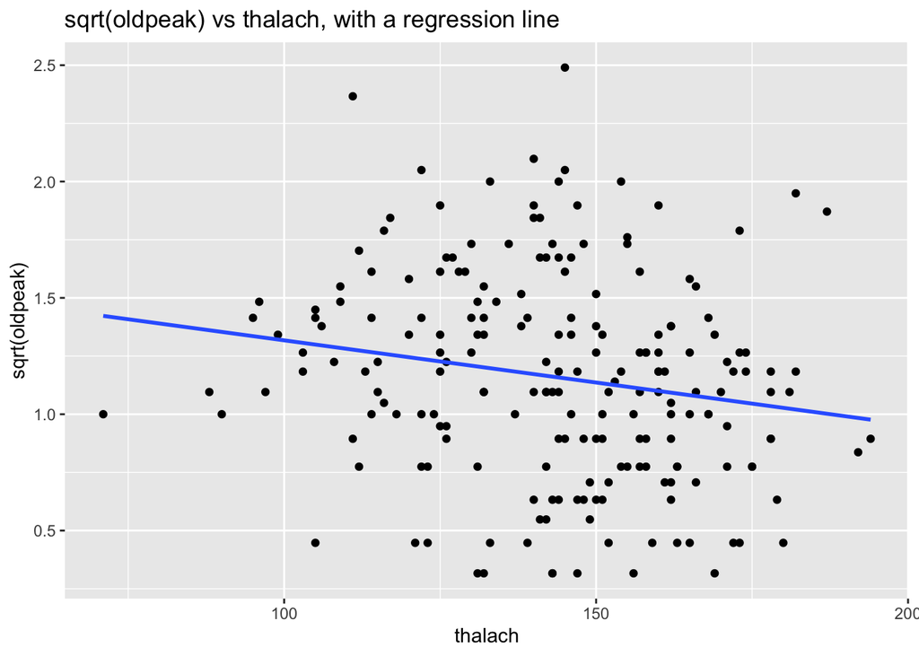

```r
ggplot(oldPeakNotZero, aes(x = thalach, y = sqrt(oldpeak))) +
geom_point() + geom_smooth(method = "lm", se = FALSE) +
  labs(title = "sqrt(oldpeak) vs thalach, with a regression line")
```

*The corresponding linear regression analysis for this line is:*

```r
summary(lm(sqrt(oldpeak) ~ thalach, data = oldPeakNotZero))
```

```
##
## Call:
## lm(formula = sqrt(oldpeak) ~ thalach, data = oldPeakNotZero)
##
## Residuals:
##      Min       1Q   Median       3Q      Max
## -0.88888 -0.29274 -0.00151  0.26370  1.33563
##
## Coefficients:
##              Estimate Std. Error t value Pr(>|t|)
## (Intercept)  1.680055   0.200868   8.364 9.86e-15 ***
## thalach     -0.003626   0.001383  -2.622   0.0094 **
## ---
## Signif. codes:  0 '***' 0.001 '**' 0.01 '*' 0.05 '.' 0.1 ' ' 1
##
## Residual standard error: 0.4414 on 202 degrees of freedom
## Multiple R-squared:  0.03292,    Adjusted R-squared:  0.02813
## F-statistic: 6.876 on 1 and 202 DF,  p-value: 0.0094
```

*From the output, we see that the estimate of the slope is -0.003626.*

# Problem 4: I have no idea what I’m doing (22 points)

[Professor M. Matsubara](https://en.wikipedia.org/wiki/Miki_Matsubara) has been trying to make scatterplots for a while and keeps getting confused, to the point that she feels like [this meme](https://i.kym-cdn.com/photos/images/newsfeed/000/234/765/b7e.jpg). She ended up making the following plots below. All four plots make the following specifications:

- `x = chol`
- `y = thalach`
- `color = target`
- `shape = sex`

The only difference among the four plots are the regression lines visualized; Plot1 shows one regression line, Plot2 and Plot3 show two regression lines, and Plot4 shows four regression lines. Compare and contrast the code Professor Matsubara wrote for these four plots, and then answer the following questions.

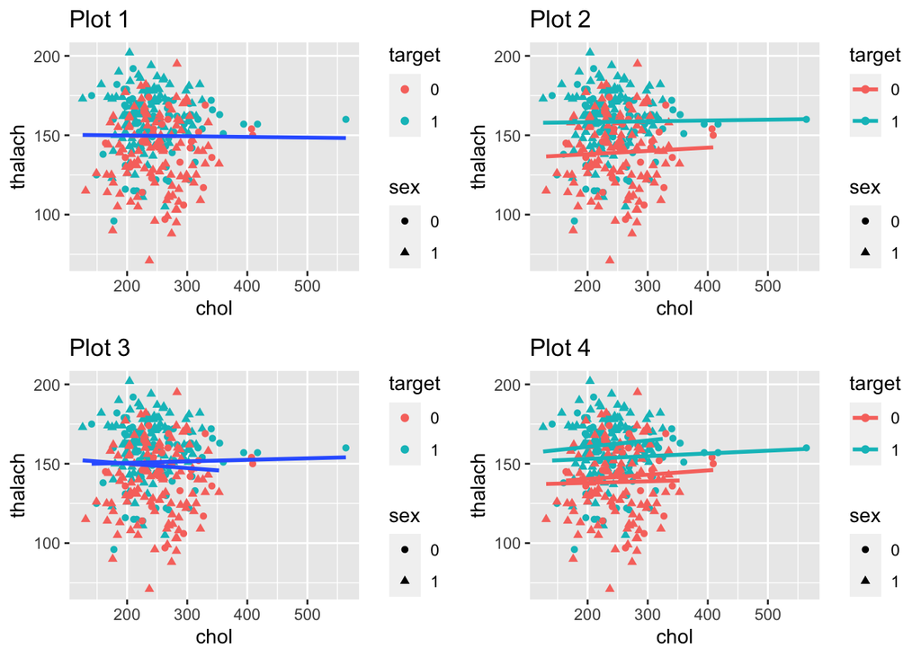

```r
library(tidyverse)
#plot1 code
plot1 = ggplot(heart,
    aes(x = chol, y = thalach)) +
geom_point(aes(color = target, shape = sex)) +
geom_smooth(method = lm, se = FALSE) + labs(title = "Plot 1")
#plot2 code
plot2 = ggplot(heart,
    aes(x = chol, y = thalach, color = target)) +
geom_point(aes(shape = sex)) +
geom_smooth(method = lm, se = FALSE) + labs(title = "Plot 2")
#plot3 code
plot3 = ggplot(heart,
    aes(x = chol, y = thalach, shape = sex)) +
geom_point(aes(color = target)) +
geom_smooth(method = lm, se = FALSE) + labs(title = "Plot 3")
#plot4 code
plot4 = ggplot(heart,
    aes(x = chol, y = thalach, shape = sex, color = target)) +
geom_point() +
geom_smooth(method = lm, se = FALSE) + labs(title = "Plot 4")

library(gridExtra)
#arrange the plot
grid.arrange(plot1, plot2, plot3, plot4)
```

1. (6pts) Professor Matsubara understands that each regression line represents a regression between `thalach` (as the outcome) and `chol` (as the covariate/predictor); however, she doesn’t understand why each plot shows different regression lines. Describe in 1-3 senteces why this happens. Then, **for each plot except Plot1**, describe to Professor Matsubara the regression lines that are being shown.

For example: Plot1 shows the regression between `thalach` and `chol` for the whole `heart` dataset (so, you don’t have to describe Plot1 to Professor Matsubara - I just did that for you!) However, the other plots have multiple regression lines, where each line represents a regression on a particular subset of data. Thus, you need to describe to Professor Matsubara which subsets are being represented as different regression lines in each plot.

*Here are the subsets that are being represented as different regression lines in each plot:*

- Plot2: *There’s a regression line for `target = 1` subjects and a regression line for `target = 0` subjects.*
- Plot3: *There’s a regression line for `sex = 1` (male) subjects and a regression line for `sex = 0` (female) subjects.*
- Plot4: *There’s a regression line for each `target` and `sex` combination: (1) `target = 1` and `sex = 1` subjects, (2) `target = 1` and `sex = 0` subjects, (3) `target = 0` and `sex = 1` subjects, and (4) `target = 0` and `sex = 0` subjects.*
2. (4pts) Now Professor Matsubara has a pretty good idea what each regression line in Plot2 represents, but she doesn’t understand what each regression line in Plot3 represents. In other words: The two regression lines in Plot3 are the same color, so she doesn’t understand which subset of data each line represents.

Copy-and-paste the Plot3 code here, and then change it such that it’s more clear what the two regression lines represent. **Make sure that the regression lines in your new plot are the same regression lines visualized in Plot3.** Then, after making your new plot, tell Professor Matsubara what each line in the plot represents; i.e., tell her which subset of data the downward-sloping line represents, and then tell her which subset of data the almost-flat line represents.

*Below we copy-and-pasted the Plot3 code, but then we set `color = sex` and `shape = target` (instead of the reverse). This gave us the following plot:*

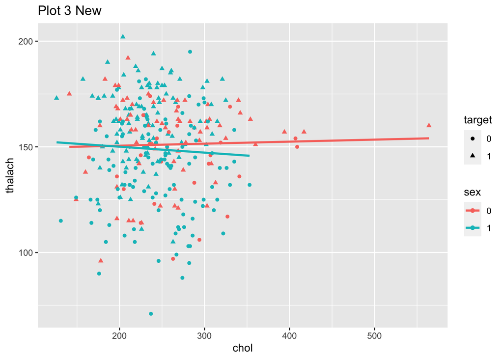

```r
ggplot(heart,
    aes(x = chol, y = thalach, color = sex)) +
geom_point(aes(shape = target)) +
geom_smooth(method = lm, se = FALSE) + labs(title = "Plot 3 New")
```

*Note that the regression lines visualized here are exactly the same as the lines in the original Plot3, but now colored by `sex`. Thus, we can see that the downward-sloping line corresponds to `sex = 1` (male) subjects, and the almost-flat line corresponds to `sex = 0` (female) subjects.*

3. (6pts) Alright, Professor Matsubara doesn’t feel as lost anymore (and she thanks you for that), but the last thing she’s confused about is Plot4. Specifically, she doesn’t understand what each of the four regression lines represent in Plot4. Answer the following questions for Professor Matsubara:
- Which subset of data does the top blue line represent in Plot4?
- Which subset of data does the bottom blue line represent in Plot4?
- Which subset of data does the top red line represent in Plot4?
- Which subset of data does the bottom red line represent in Plot4?

It will be helpful for you to create **two scatterplots (with regression lines)** to help you figure out the answer to these questions. Some of the following subsets of data may be helpful to you (but some may not be):

```r
target1Data = subset(heart, target == 1)
target0Data = subset(heart, target == 0)
maleData = subset(heart, sex == 1)
femaleData = subset(heart, sex == 0)
```

**In addition to answering the four questions above, be sure to include the two graphs you used to arrive at your answer.** Make sure that your plots are appropriately titled/labeled so that Professor Matsubara can understand what you are plotting.

*Note that Plot4 is colored by the `target` variable, and we noted in Part A that Plot4 visualizes a regression line for each `target` and `sex` combination. Thus, the two blue lines correspond to `target = 1` subjects and the two red lines correspond to `target = 0` subjects; however, we don’t know which `sex` subset each line corresponds to. To determine this, we can use the exact same approach as Part B, but for the `target = 1` and `target = 0` subsets of the data.*

*Below we make two plots: One for `target = 1` subjects and one for `target = 0` subjects. In each plot, regression lines are colored by `sex`.*

*First, here’s the `target = 1` plot:*

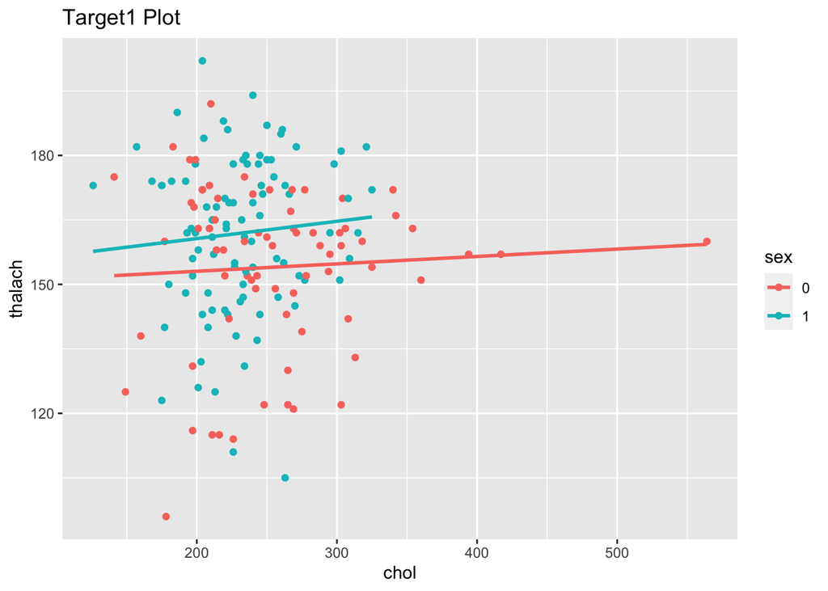

```r
ggplot(target1Data,
    aes(x = chol, y = thalach, color = sex)) +
geom_point() +
geom_smooth(method = lm, se = FALSE) + labs(title = "Target1 Plot")
```

*Looking back at Plot4, we can see that these are indeed the two blue regression lines in Plot4 (because both lines are above `thalach = 150`).*

*Now, here’s the `target = 0` plot:*

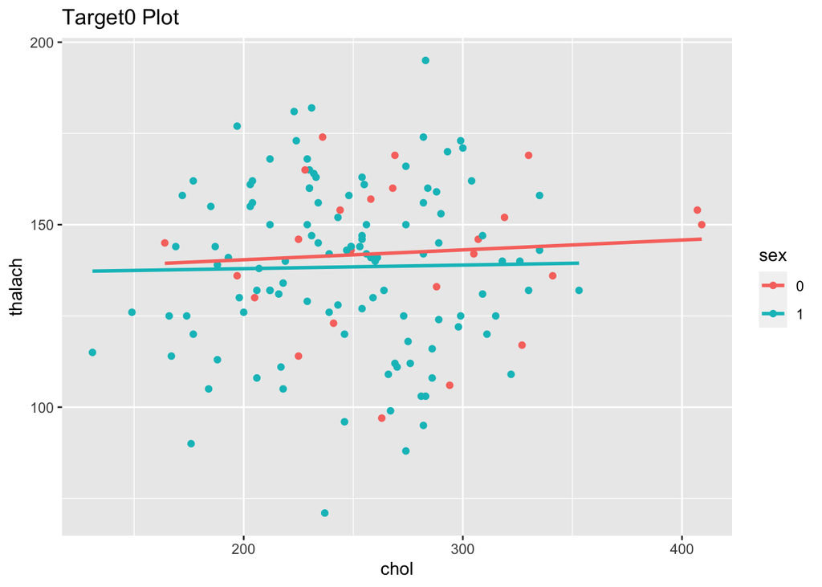

```r
ggplot(target0Data,
    aes(x = chol, y = thalach, color = sex)) +
geom_point() +
geom_smooth(method = lm, se = FALSE) + labs(title = "Target0 Plot")
```

*Looking back at Plot4, we can see that these are indeed the two red regression lines in Plot4 (because both lines are below `thalach = 150`).*

*Looking at the above plots, now we can give the following answers to Professor Matsubara’s questions:*

- Which subset of data does the top blue line represent in Plot4?

*This represents `target = 1` and `sex = 1` (male) subjects.*

- Which subset of data does the bottom blue line represent in Plot4?

*This represents `target = 1` and `sex = 0` (female) subjects.*

- Which subset of data does the top red line represent in Plot4?

*This represents `target = 0` and `sex = 0` (female) subjects.*

- Which subset of data does the bottom red line represent in Plot4?

*This represents `target = 0` and `sex = 1` (male) subjects.*

4. (6pts) Professor Matsubara says, “Thank you so much for helping me figure out these plots. After looking at these plots, I decided to run the following regression model:”

```r
summary(lm(thalach ~ chol*sex, data = heart))
```

```
##
## Call:
## lm(formula = thalach ~ chol * sex, data = heart)
##
## Residuals:
##     Min      1Q  Median      3Q     Max
## -78.025 -15.033   3.093  16.517  52.052
##
## Coefficients:
##               Estimate Std. Error t value Pr(>|t|)
## (Intercept) 148.621939   9.748500  15.246   <2e-16 ***
## chol          0.009579   0.036212   0.265    0.792
## sex1          7.030213  13.331621   0.527    0.598
## chol:sex1    -0.037540   0.052068  -0.721    0.471
## ---
## Signif. codes:  0 '***' 0.001 '**' 0.01 '*' 0.05 '.' 0.1 ' ' 1
##
## Residual standard error: 22.97 on 299 degrees of freedom
## Multiple R-squared:  0.004031,   Adjusted R-squared:  -0.005962
## F-statistic: 0.4034 on 3 and 299 DF,  p-value: 0.7506
```

Answer the following questions for Professor Matsubara:

- Which of the four plots (Plot1, Plot2, Plot3, or Plot4) is visualizing the regression model that Professor Matsubara just ran? Explain how you arrived at your answer in 1-2 sentences.

*This regression model is being visualized by Plot3. Plot3 has separate regression lines for each `sex` group (as we discussed in Part A), and here we are including `sex` in the regression to obtain a different intercept and slope for each `sex` group (as we elaborate on below).*

*To help with answering the questions below: Note that this linear regression is making the following modeling specification:*

$$\text{thalach} \sim N(\beta_0 + \beta_C \cdot \text{chol} + \beta_M \cdot I_M + \beta_{CM} \cdot \text{chol} \cdot I_M, \sigma^2)$$

where $I_M = 1$ for male (`sex = 1`) subjects and $I_M = 0$ for female (`sex = 0`) subjects. Therefore, according to this model, the mean `thalach` for male subjects is:

$$(\beta_0 + \beta_M) + (\beta_C + \beta_{CM}) \cdot \text{chol}$$

and the mean `thalach` for female subjects is:

$$\beta_0 + \beta_C \cdot \text{chol}$$

- According to the above model, what is the estimated intercept for female subjects? What is the estimated slope for female subjects? (Your answer should be just two numbers; do your best to show your work.)

*From the above, we can see that the intercept for female subjects is $\beta_0$; the estimate for this is 148.62. Meanwhile, the slope is $\beta_C$; the estimate is 0.01.*

- According to the above model, what is the estimated intercept for male subjects? What is the estimated slope for male subjects? (Your answer should be just two numbers; do your best to show your work.)

*From the above, we can see that the intercept for male subjects is $\beta_0 + \beta_M$; the estimate for this is $148.62 + 7.03 = 155.65$. Meanwhile, the slope is $\beta_C + \beta_{CM}$; the estimate is $0.01 - 0.04 = -0.03$.*